# titanic_train_data-Copy1

```
                                         Introduction
```

I have taken a "titanic.csv dataset" for my analysis purpose. Titanic sank after colliding with an iceberg, killing 1502 out of 2224 passengers and crew. One of the reasons that the shipwreck led to such loss of life was that there were not enough lifeboats for the passengers and crew. Although there was some element of luck involved in surviving the sinking, some groups of people were more likely to survive than others, such as women, children, and the upper-class.

Steps take to prepare the data: Finding types for various features. Replace missing values from some features. Distribution of numerical feature values across the samples.

I have take some assumtions based on data analysis like correlating,completing,correcting,creating and classifying.

In this challenge,I am going to complete the analysis of what sorts of people were likely to survive.

I will focus on doing some illustrative data visualizations along the way.

The data has been split into two groups: training set (train.csv) test set (test.csv) let's import the train and test csv file.

```python
import pandas as pd
import numpy as np
import random as rnd
import seaborn as sns

train_df = pd.read_csv("/home/aunja/Desktop/titanic_data/train.csv")
test_df = pd.read_csv("/home/aunja/Desktop/titanic_data/test.csv")
Combine = [train_df, test_df]
print (Combine)
```

[output not shown]

[output cut: 364 more lines]

```python
#features are available in the dataset
print(train_df.columns.values)
```

```
['PassengerId' 'Survived' 'Pclass' 'Name' 'Sex' 'Age' 'SibSp' 'Parch'
 'Ticket' 'Fare' 'Cabin' 'Embarked']
```

Descriptions of features(column name): Survived, Sex, and Embarked. Ordinal: Pclass are categorical data Age, Fare. Discrete: SibSp, Parch. are numerical data. Ticket is a mix of numeric and alphanumeric data types. Cabin is alphanumeric. Name feature may contain errors or typos as there are several ways used to describe a name including titles,round brackets,and quotes used for alternative or short names. Cabin > Age > Embarked features contain a number of null values in that order for the training dataset. Cabin > Age are incomplete in case of test dataset.

Variable Notes: pclass: A proxy for socio-economic status (SES) 1st = Upper 2nd = Middle 3rd = Lower

age: Age is fractional if less than 1. If the age is estimated, is it in the form of xx.5

sibsp: The dataset defines family relations in this way... Sibling = brother, sister, stepbrother, stepsister Spouse = husband, wife (mistresses and fiancés were ignored)

parch: The dataset defines family relations in this way... Parent = mother, father Child = daughter, son, stepdaughter, stepson Some children travelled only with a nanny, therefore parch=0 for them.

I have taken 1 to 650 rows for analysis.There is not any specific reason for selecting 650 rows.

```python
new_train_data = train_df.head(650)
```

```python
new_train_data.head()
```

|  | PassengerId | Survived | Pclass | Name | Sex | Age | SibSp | Parch | Ticket | Fare | Cabin | Embarked |
| --- | --- | --- | --- | --- | --- | --- | --- | --- | --- | --- | --- | --- |
| 0 | 1 | 0 | 3 | Braund, Mr. Owen Harris | male | 22 | 1 | 0 | A/5 21171 | 7.2500 | NaN | S |
| 1 | 2 | 1 | 1 | Cumings, Mrs. John Bradley (Florence Briggs Th... | female | 38 | 1 | 0 | PC 17599 | 71.2833 | C85 | C |
| 2 | 3 | 1 | 3 | Heikkinen, Miss. Laina | female | 26 | 0 | 0 | STON/O2. 3101282 | 7.9250 | NaN | S |
| 3 | 4 | 1 | 1 | Futrelle, Mrs. Jacques Heath (Lily May Peel) | female | 35 | 1 | 0 | 113803 | 53.1000 | C123 | S |
| 4 | 5 | 0 | 3 | Allen, Mr. William Henry | male | 35 | 0 | 0 | 373450 | 8.0500 | NaN | S |

```python
new_train_data.tail()
```

|  | PassengerId | Survived | Pclass | Name | Sex | Age | SibSp | Parch | Ticket | Fare | Cabin | Embarked |
| --- | --- | --- | --- | --- | --- | --- | --- | --- | --- | --- | --- | --- |
| 645 | 646 | 1 | 1 | Harper, Mr. Henry Sleeper | male | 48 | 1 | 0 | PC 17572 | 76.7292 | D33 | C |
| 646 | 647 | 0 | 3 | Cor, Mr. Liudevit | male | 19 | 0 | 0 | 349231 | 7.8958 | NaN | S |
| 647 | 648 | 1 | 1 | Simonius-Blumer, Col. Oberst Alfons | male | 56 | 0 | 0 | 13213 | 35.5000 | A26 | C |
| 648 | 649 | 0 | 3 | Willey, Mr. Edward | male | 42 | 0 | 0 | S.O./P.P. 751 | 7.5500 | NaN | S |
| 649 | 650 | 1 | 3 | Stanley, Miss. Amy Zillah Elsie | female | 23 | 0 | 0 | CA. 2314 | 7.5500 | NaN | S |

```python
#What are the data types for various features?
#Seven features are integer or floats.
#Five features are strings (object).

new_train_data.info()
print('_'*80)
```

[output not shown]

```python
print ((new_train_data['Survived'] == 1).sum())
print ((new_train_data['Survived'] == 0).sum())
```

```
256
394
```

There are some missing values (null values)in the data sets. From the data set, we notice that there are missing values in Age, Cabin and Embarked column. We are going to replace missing values in Age with a random sample from existing ages. For Cabin, since cabin number makes little sense to the result, It has a lot of NaN values, so it won't cause a remarkable impact on data analysis.

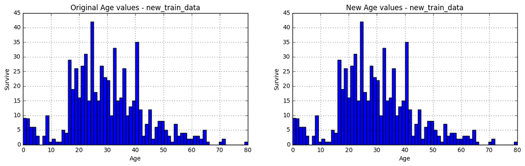

```python
import matplotlib.pyplot as plt

fig, (axis1,axis2) = plt.subplots(1,2,figsize=(15,4))
axis1.set_title('Original Age values - new_train_data')
axis2.set_title('New Age values - new_train_data')
axis1.set_xlabel("Age")
axis1.set_ylabel("Survive")
axis2.set_xlabel("Age")
axis2.set_ylabel("Survive")


# get average, std, and number of NaN values in  new_train_data
average_age_new_train_data  = new_train_data["Age"].mean()
std_age_new_train_data      = new_train_data["Age"].std()
count_nan_age_new_train_data = new_train_data["Age"].isnull().sum()

# generate random numbers between (mean - std) & (mean + std)
rand_1 = np.random.randint(average_age_new_train_data - std_age_new_train_data, average_age_new_train_data + std_age_new_train_data, size = count_nan_age_new_train_data)

# plot original Age values
# NOTE: drop all null values, and convert to int
new_train_data['Age'].dropna().astype(int).hist(bins=70, ax=axis1)


# fill NaN values in Age column with random values generated
new_train_data["Age"][np.isnan(new_train_data["Age"])] = rand_1

# convert from float to int
new_train_data['Age'] = new_train_data['Age'].astype(int)


# plot new Age Values
new_train_data['Age'].hist(bins=70, ax=axis2)
#plt.xlabel('Age')
#plt.ylabel('survive')
plt.show()
```

As we can see, the graph does not represent a normal distribution. Any sort of assumptions based on distribution or the mean(Age) will be affected.

```python
new_train_data.describe()
```

|  | PassengerId | Survived | Pclass | Age | SibSp | Parch | Fare |
| --- | --- | --- | --- | --- | --- | --- | --- |
| count | 650.00000 | 650.000000 | 650.000000 | 650.000000 | 650.000000 | 650.000000 | 650.000000 |
| mean | 325.50000 | 0.393846 | 2.309231 | 29.643077 | 0.535385 | 0.383077 | 31.450063 |
| std | 187.78312 | 0.488978 | 0.837161 | 13.607371 | 1.076207 | 0.804086 | 45.087844 |
| min | 1.00000 | 0.000000 | 1.000000 | 0.000000 | 0.000000 | 0.000000 | 0.000000 |
| 25% | 163.25000 | 0.000000 | 2.000000 | 21.000000 | 0.000000 | 0.000000 | 7.925000 |
| 50% | 325.50000 | 0.000000 | 3.000000 | 28.000000 | 0.000000 | 0.000000 | 15.047900 |
| 75% | 487.75000 | 1.000000 | 3.000000 | 38.000000 | 1.000000 | 0.000000 | 30.646850 |
| max | 650.00000 | 1.000000 | 3.000000 | 80.000000 | 8.000000 | 5.000000 | 512.329200 |

The distribution of categorical features. Names are unique across the dataset (count=unique=650). Cabin values have several dupicates across samples. Alternatively several passengers shared a cabin. Embarked takes three possible values."S","C","Q". where S port used by most passengers (top=S).

```python
print ((new_train_data['Embarked'] == 'S').sum())
print ((new_train_data['Embarked'] == 'C').sum())
print ((new_train_data['Embarked'] == 'Q').sum())
```

```
465
126
58
```

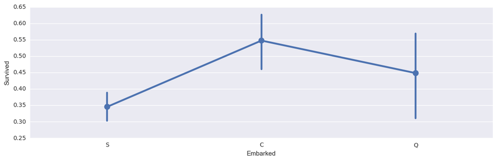

```python
# Embarked

# only in titanic_df, fill the two missing values with the most occurred value, which is "S".

new_train_data["Embarked"] = new_train_data["Embarked"].fillna("S")

# plot
sns.factorplot('Embarked','Survived', data=new_train_data,size=4,aspect=3)
plt.show()
```

```python
new_train_data.describe(include=['O'])
```

|  | Name | Sex | Ticket | Cabin | Embarked |
| --- | --- | --- | --- | --- | --- |
| count | 650 | 650 | 650 | 147 | 650 |
| unique | 650 | 2 | 524 | 110 | 3 |
| top | Weisz, Mrs. Leopold (Mathilde Francoise Pede) | male | 347082 | C23 C25 C27 | S |
| freq | 1 | 411 | 5 | 4 | 466 |

Assumtions based on data analysis We arrive at following assumptions based on data analysis done so far. We may validate these assumptions further before taking appropriate actions.

Correlating. We want to know how well does each feature correlate with Survival. We want to do this early in our project and match these quick correlations with modelled correlations later in the project.

Completing. We may want to complete Age feature as it is definitely correlated to survival. We may want to complete the Embarked feature as it may also correlate with survival or another important feature.

Correcting. Ticket feature may be dropped from our analysis as it contains high ratio of duplicates and there may not be a correlation between Ticket and survival. Cabin feature may be dropped as it is highly incomplete or contains many null values. PassengerId may be dropped from training dataset as it does not contribute to survival. Name feature is relatively non-standard, may not contribute directly to survival, so maybe dropped.

Creating. We may want to create a new feature called Family based on Parch and SibSp to get total count of family members on board. We may want to engineer the Name feature to extract Title as a new feature. We may want to create new feature for Age bands. This turns a continous numerical feature into an ordinal categorical feature.

Now I have to take some features for doing the analysis. I can only do so at this stage for features which do not have any empty values. It also makes sense doing so only for features which are categorical (Sex), ordinal (Pclass) or discrete (SibSp, Parch) type.

Pclass feature for analysis:

```python
new_train_data[['Pclass', 'Survived']].groupby(['Pclass'], as_index=False).mean().sort_values(by='Survived',
                                                                                              ascending=False)
```

|  | Pclass | Survived |
| --- | --- | --- |
| 0 | 1 | 0.607595 |
| 1 | 2 | 0.511278 |
| 2 | 3 | 0.256267 |

Pclass We observe significant correlation (>0.5) among Pclass=1 and Survived. We decide to include this feature in my model.

Sex fetaure for analysis:

```python
new_train_data[["Sex", "Survived"]].groupby(['Sex'], as_index=False).mean().sort_values(by='Survived', ascending=False)
```

|  | Sex | Survived |
| --- | --- | --- |
| 0 | female | 0.744770 |
| 1 | male | 0.189781 |

Sex We confirm the observation during problem definition that Sex=female had very high survival rate at 74%.

SibSp feature for analysis:

```python
new_train_data[["SibSp", "Survived"]].groupby(['SibSp'], as_index=False).mean().sort_values(by='Survived', ascending=False)
```

|  | SibSp | Survived |
| --- | --- | --- |
| 1 | 1 | 0.532051 |
| 2 | 2 | 0.478261 |
| 0 | 0 | 0.357798 |
| 4 | 4 | 0.230769 |
| 3 | 3 | 0.214286 |
| 5 | 5 | 0.000000 |
| 6 | 8 | 0.000000 |

Parch feature for analysis:

```python
new_train_data[["Parch", "Survived"]].groupby(['Parch'], as_index=False).mean().sort_values(by='Survived',
                                                                                            ascending=False)
```

|  | Parch | Survived |
| --- | --- | --- |
| 2 | 2 | 0.539683 |
| 1 | 1 | 0.506173 |
| 3 | 3 | 0.500000 |
| 0 | 0 | 0.360887 |
| 5 | 5 | 0.250000 |
| 4 | 4 | 0.000000 |

Age feature for analysis:

```python
new_train_data[["Age", "Survived"]].groupby(['Age'], as_index=False).mean().sort_values(by='Survived',
                                                                                            ascending=False)
```

[output not shown]

81 rows × 2 columns

Analyze by visualizing data:

Correlating numerical features We have to understand correlations between numerical features and our solution goal (Survived). A histogram chart is useful for analyzing continous numerical variables like Age where banding or ranges will help identify useful patterns. The histogram can indicate distribution of samples using automatically defined bins or equally ranged bands.

Observations. Infants (Age <=4) had high survival rate. Oldest passengers (Age = 80) survived. Large number of 15-35 year olds did not survive. Most passengers are in 15-40 age range.

```python
import matplotlib.pyplot as plt
import seaborn as sns

g = sns.FacetGrid(new_train_data, col='Survived')
g.map(plt.hist, 'Age', bins=20)
plt.show()
```

[output not shown]

Consider Pclass for model training.

Correlating numerical and ordinal features:

Decisions. Consider Pclass for model training.

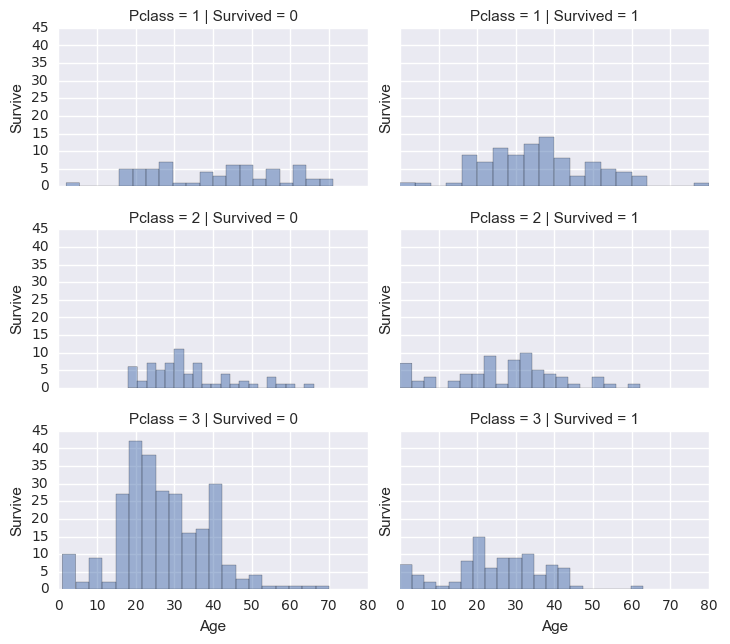

```python
grid = sns.FacetGrid(new_train_data, col='Survived', row='Pclass', size=2.2, aspect=1.6)
grid.map(plt.hist, 'Age', alpha=.5, bins=20)
grid.set(ylabel="Survive")
grid.add_legend();
plt.show()
```

Correlating categorical features

Decisions. Add Sex feature to model training. Complete and add Embarked feature to model training.

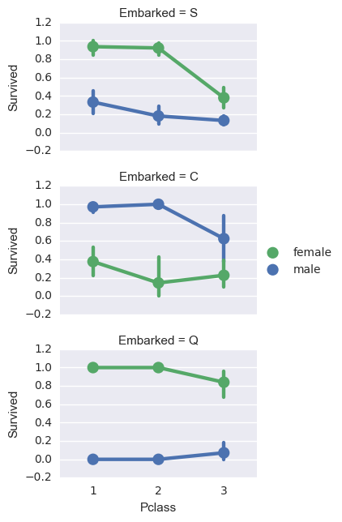

```python
grid = sns.FacetGrid(new_train_data, row='Embarked', size=2.2, aspect=1.6)
grid.map(sns.pointplot, 'Pclass', 'Survived','Sex', palette='deep')
grid.add_legend()
plt.show()
```

Correlating categorical and numerical features We may also want to correlate categorical features (with non-numeric values) and numeric features. We can consider correlating Embarked (Categorical non-numeric), Sex (Categorical non-numeric), Fare (Numeric continuous), with Survived (Categorical numeric). Observations. Higher fare paying passengers had better survival. Port of embarkation correlates with survival rates. Consider banding Fare feature.

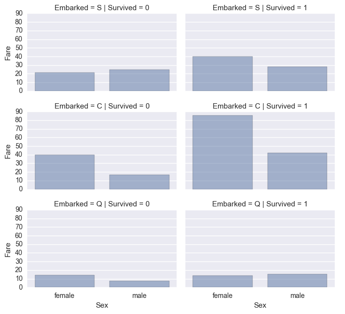

```python
grid = sns.FacetGrid(new_train_data, row='Embarked', col='Survived', size=2.2, aspect=1.6)
grid.map(sns.barplot, 'Sex', 'Fare', alpha=.5, ci=None)
grid.add_legend()
plt.show()
```

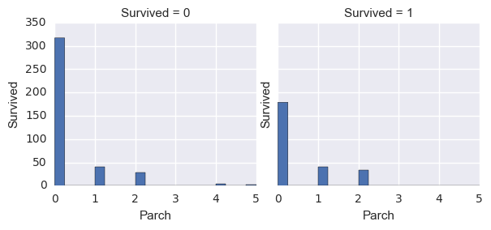

```python
g = sns.FacetGrid(new_train_data, col='Survived')
g.map(plt.hist, 'Parch', bins=20)
g.set(ylabel="Survived")
plt.show()
```

Data Wrangle

I have collected several assumptions and decisions regarding our datasets and solution requirements. So far I did not have to change a single feature or value to arrive at these. Let us now execute our decisions and assumptions for correcting, creating, and completing goals.

Correcting by dropping features

This is a good starting goal to execute. By dropping features we are dealing with fewer data points. Speeds up our notebook and eases the analysis. Based on our assumptions and decisions I want to drop the Cabin and Ticket features.

```python
print("Before", new_train_data.shape, new_test_data.shape, combine[0].shape, combine[1].shape)

new_train_data = new_train_data.drop(['Ticket', 'Cabin'], axis=1)
#
new_test_data = new_test_data.drop(['Ticket', 'Cabin'], axis=1)
combine = [new_train_data, new_test_data]

"After", new_train_data.shape, new_test_data.shape, combine[0].shape, combine[1].shape
```

```
Before (650, 12) (418, 11) (891, 12) (418, 11)
```

```
('After', (650, 10), (418, 9), (650, 10), (418, 9))
```

```
                      Creating new feature extracting from existing
```

I want to analyze if Name feature can be engineered to extract titles and test correlation between titles and survival, before dropping Name and PassengerId features. In the following code we extract Title feature using regular expressions. The RegEx pattern (\w+.) matches the first word which ends with a dot character within Name feature. The expand=False flag returns a DataFrame.

Decision. I decide to retain the new Title feature for model training.

```python
for dataset in combine:
    dataset['Title'] = dataset.Name.str.extract(' ([A-Za-z]+)\.', expand=False)

pd.crosstab(new_train_data['Title'], new_train_data['Sex'])
```

| Sex Title | female | male |
| --- | --- | --- |
| Col | 0 | 1 |
| Don | 0 | 1 |
| Dr | 0 | 4 |
| Lady | 1 | 0 |
| Major | 0 | 2 |
| Master | 0 | 27 |
| Miss | 145 | 0 |
| Mlle | 1 | 0 |
| Mme | 1 | 0 |
| Mr | 0 | 371 |
| Mrs | 90 | 0 |
| Ms | 1 | 0 |
| Rev | 0 | 4 |
| Sir | 0 | 1 |

I can replace many titles with a more common name or classify them as Rare.

```python
for dataset in combine:
    dataset['Title'] = dataset['Title'].replace(['Lady', 'Countess','Capt', 'Col',\
 	'Don', 'Dr', 'Major', 'Rev', 'Sir', 'Jonkheer', 'Dona'], 'Rare')

    dataset['Title'] = dataset['Title'].replace('Mlle', 'Miss')
    dataset['Title'] = dataset['Title'].replace('Ms', 'Miss')
    dataset['Title'] = dataset['Title'].replace('Mme', 'Mrs')

new_train_data[['Title', 'Survived']].groupby(['Title'], as_index=False).mean()
```

|  | Title | Survived |
| --- | --- | --- |
| 0 | Master | 0.518519 |
| 1 | Miss | 0.714286 |
| 2 | Mr | 0.161725 |
| 3 | Mrs | 0.791209 |
| 4 | Rare | 0.357143 |

I can convert the categorical titles to ordinal.

```python
title_mapping = {"Mr": 1, "Miss": 2, "Mrs": 3, "Master": 4, "Rare": 5}
for dataset in combine:
    dataset['Title'] = dataset['Title'].map(title_mapping)
    dataset['Title'] = dataset['Title'].fillna(0)

new_train_data.head()
```

|  | PassengerId | Survived | Pclass | Name | Sex | Age | SibSp | Parch | Fare | Embarked | Title |
| --- | --- | --- | --- | --- | --- | --- | --- | --- | --- | --- | --- |
| 0 | 1 | 0 | 3 | Braund, Mr. Owen Harris | male | 22.0 | 1 | 0 | 7.2500 | S | 1 |
| 1 | 2 | 1 | 1 | Cumings, Mrs. John Bradley (Florence Briggs Th... | female | 38.0 | 1 | 0 | 71.2833 | C | 3 |
| 2 | 3 | 1 | 3 | Heikkinen, Miss. Laina | female | 26.0 | 0 | 0 | 7.9250 | S | 2 |
| 3 | 4 | 1 | 1 | Futrelle, Mrs. Jacques Heath (Lily May Peel) | female | 35.0 | 1 | 0 | 53.1000 | S | 3 |
| 4 | 5 | 0 | 3 | Allen, Mr. William Henry | male | 35.0 | 0 | 0 | 8.0500 | S | 1 |

Now I can safely drop the Name feature from training and testing datasets. We also do not need the PassengerId feature in the training dataset.

```python
new_train_data = new_train_data.drop(['Name', 'PassengerId'], axis=1)
new_test_data = new_test_data.drop(['Name'], axis=1)
combine = [new_train_data, new_test_data]
new_train_data.shape, new_test_data.shape
```

```
((650, 9), (418, 9))
```

Converting a categorical feature

```python
for dataset in combine:
    dataset['Sex'] = dataset['Sex'].map( {'female': 1, 'male': 0} ).astype(int)

new_train_data.head()
```

|  | Survived | Pclass | Sex | Age | SibSp | Parch | Fare | Embarked | Title |
| --- | --- | --- | --- | --- | --- | --- | --- | --- | --- |
| 0 | 0 | 3 | 0 | 22.0 | 1 | 0 | 7.2500 | S | 1 |
| 1 | 1 | 1 | 1 | 38.0 | 1 | 0 | 71.2833 | C | 3 |
| 2 | 1 | 3 | 1 | 26.0 | 0 | 0 | 7.9250 | S | 2 |
| 3 | 1 | 1 | 1 | 35.0 | 1 | 0 | 53.1000 | S | 3 |
| 4 | 0 | 3 | 0 | 35.0 | 0 | 0 | 8.0500 | S | 1 |

Completing a numerical continuous feature

Now we should start estimating and completing features with missing or null values. We will first do this for the Age feature. We can consider three methods to complete a numerical continuous feature. 1- A simple way is to generate random numbers between mean and standard deviation. 2- More accurate way of guessing missing values is to use other correlated features. In our case we note  
correlation among Age, Gender, and Pclass. Guess Age values using median values for Age across sets of Pclass  
and Gender feature combinations. So, median Age for Pclass=1 and Gender=0, Pclass=1 and Gender=1, and so on... 3- Combine methods 1 and 2. So instead of guessing age values based on median, use random numbers between mean and  
standard deviation, based on sets of Pclass and Gender combinations.

Method 1 and 3 will introduce random noise into our models. The results from multiple executions might vary. Hence we will prefer method 2.

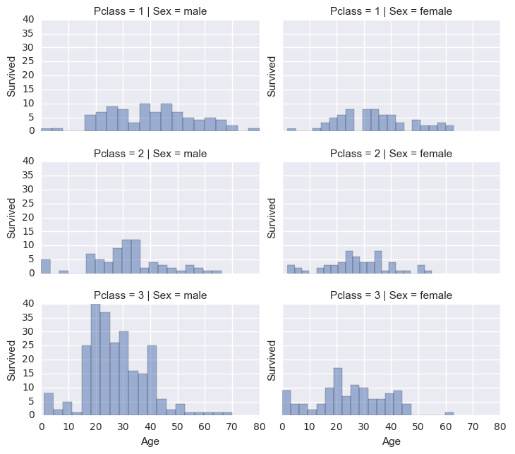

```python
grid = sns.FacetGrid(new_train_data, row='Pclass', col='Sex', size=2.2, aspect=1.6)
grid.map(plt.hist, 'Age', alpha=.5, bins=20)
grid.set(ylabel="Survived")
grid.add_legend()
plt.show()
```

```
                                          Conclusion
```

Embarked "S"=465 Embarked "C"=126 Embarked "Q"=58 S port used by most passengers (top=S).